# Tutorial de búsqueda y análisis bibliométrico con OpenAlex y Biblioshiny

# Introducción

Este tutorial describe un flujo de trabajo completo para realizar un análisis bibliométrico usando herramientas abiertas. Se compone de los siguientes pasos:

1. **Buscar y descargar los datos bibliográficos**, puede utilizarse la App de epistemonikos o la App de openalex que desarrollamos. Tambien hay otras opciones.
2. **Cargar esos datos en `biblioshiny`**, una aplicación web basada en R para análisis bibliométrico interactivo.
3. **Explorar y descargar resultados** (tablas y gráficos) desde biblioshiny, ya sea en formato Excel o imágenes.
4. **Interpretar las salidas** para generar conocimiento sobre tendencias, autores clave, colaboraciones y producción científica.

Este flujo de trabajo permite realizar análisis bibliométricos de forma transparente y reproducible, utilizando exclusivamente datos abiertos y herramientas libres.

# 1. Búsqueda y descarga de datos

## 1.1 Acceso a la aplicación OPENALEX

Podés acceder a la app Shiny desde el siguiente enlace :

**👉 [Acceder a la app Shiny OpenAlex](https://paho.shinyapps.io/Descarga_openalex/)**

## 1.2 Instrucciones de uso

1. **Ingresá el términos de búsqueda** en el campo de texto. Ejemplo: lung cancer, non-small cell lung carcinoma.

   ⚠️ **Importante:** Para realizar búsquedas que contengan más de un término, ingresá los términos separados por AND por ejemplo:

   `lung cancer AND breast cancer`.

   Si necesitas búsquedas con dos o más términos diferentes recomendamos hacer dos descargar por separado (una por termino) ya que más d eun término puede ser demasiado amplio- Hay un límite en el tamaño del archivo a procesar por las app y puede frenarse el proceso o dejarlo inconcluso si es demasiado grande. Si esto no es posible podemos compartir el codigo de la app para que lo puedan correr localmente y obtener bases de datos de mayor tamaño. Tener en cuenta que un tamaño demasiado grande volverá, también, mas lento y difícil el posterior proceso de análisis.
2. **Definí el rango de años** de interés (desde y hasta).
3. **Seleccioná el umbral mínimo de citas** que deben tener los artículos para ser incluidos. Este parámetro permite filtrar los artículos según su impacto académico, incluyendo solo aquellos que hayan sido citados al menos una cierta cantidad de veces. Este umbral se aplica mediante el filtro cited_by_count = “>X” en la API de OpenAlex, donde X es el número ingresado por el usuario. Por ejemplo, si se establece en 30, se recuperarán únicamente los artículos con más de 30 citas. Este criterio es útil para priorizar trabajos influyentes y reducir el volumen de resultados, aunque puede ajustarse a valores menores si se desea incluir investigaciones recientes o de menor visibilidad.
4. Presioná el botón `Buscar y procesar datos`.

**Nota**

Durante el proceso se muestra un progreso estimado de descarga y procesamiento.

5. Al finalizar, podrás descargar el archivo en formato `.xlsx` y guardarlo en una carpeta de tu PC, listo para usar en `biblioshiny`.

## 1.3 Acceso a la aplicación EPISTEMONIKOS

**👉** [Acceder a la app Shiny EPISTEMONIKOS](https://paho.shinyapps.io/epitemonikos2/)

# 2. Uso de los datos en Biblioshiny

## 2.1 Acceso a Biblioshiny

Dos opicones para acceder:

1. Con algunos limites de uso, enlace directo con deploy hecho por nosotros:

   **👉 https://paho.shinyapps.io/biblioshiny/**
2. Ingresá a Posit Cloud y accedé a nuestro proyecto con `biblioshiny` instalado.

Enlace para ingresar al espacio de posit.cloud: https://posit.cloud/spaces/60706/join?access_code=63Gg34jn5jzzRykGMaxnYA34NF3cMwz_GRBdewaI

Ingresar al proyecto señalado:

[figure not shown]

[figure not shown]

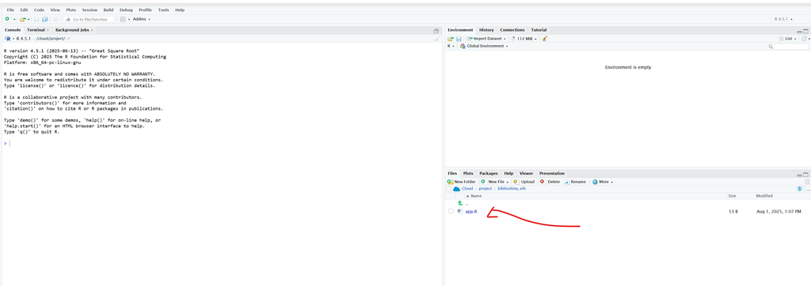

Hacer clic en SOURCE para correr la app de biblioshiny.

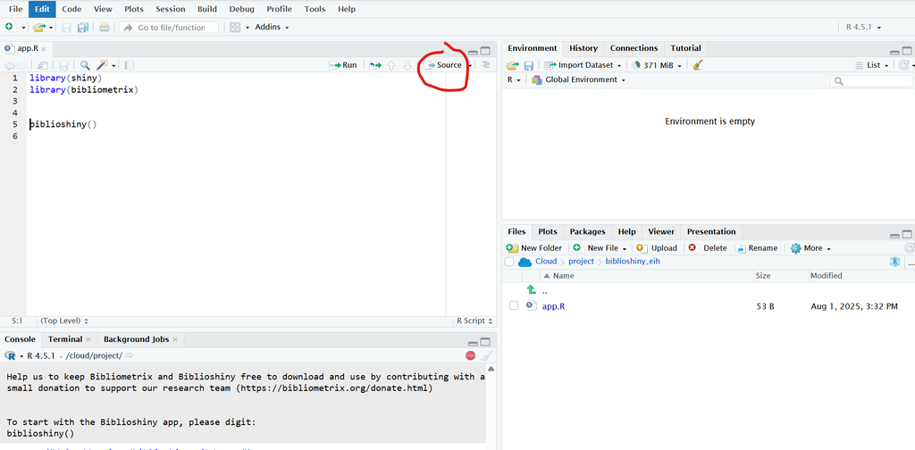

Con este último paso se abrirá, en una nueva pestaña, la aplicación de biblioshiny.

[figure not shown]

## 2.2 Cargar el archivo descargado

1. En la pantalla principal, hacé clic en Data - Import or Load. Load bibliometrix file(s).

[figure not shown]

2. Seleccioná el archivo `.xlsx` o `.RData` que descargaste previamente desde la app Shiny haciendo clic en Browse y presione START.

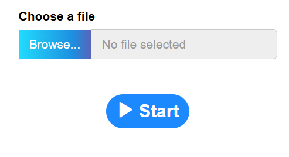

# 3. Interpretación de los gráficos e indicadores

Una vez realizado los pasos anteriores se desplegará un menu con los diferenten analisis que pertite hacer el programa.

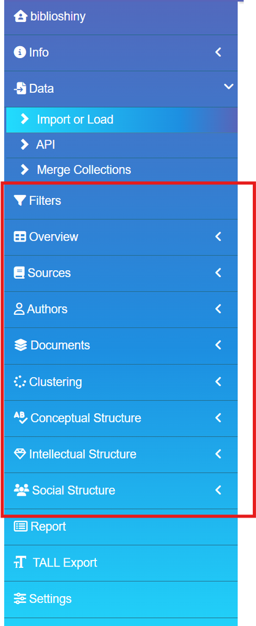

Veremos cada una de estas secciones, para ayudarle a comprender estos indicadores y graficos.

Es importante que sepa que podra elegir que graficos e indicadores desea incluir en el informe final. Eso lo podra realizar presionando el botón de + al lado de botón play que genera los graficos (señalado en rojo en la imagen siguiente).

[figure not shown]

## 📊 Sección Overview

Muestra una visión general de los datos cargados.

### Producción científica anual (Annual Scientific Production)

¿Qué muestra?  
Este gráfico de línea representa la cantidad de artículos **publicados por año** dentro del conjunto de datos cargado.

**Eje X:** Años de publicación.  
**Eje Y:** Número de artículos.

**¿Cómo se calcula?**  
Cuenta el número de documentos (típicamente `ARTICLE`, `REVIEW`, etc.) publicados por año según el campo `PY` (Publication Year) de la base.

**¿Para qué sirve?**

- Evalúa la **evolución de la producción científica**.
- Útil para identificar picos o caídas en publicaciones que pueden estar relacionados con:

```
-    Eventos mundiales (ej. pandemia).

-    Cambios en financiamiento, políticas, convocatorias.

-    Interés creciente o decreciente en un tema.
```

### Citas promedio por año (Average citations per year)

**¿Qué muestra?**  
Este gráfico de línea muestra la cantidad **promedio de citas por artículo** en cada año.

**Eje X:** Años de publicación.  
**Eje Y:** Promedio de citas recibidas por artículo publicado ese año.

**¿Para qué sirve?**

- **Detecta tendencias de impacto:** este gráfico permite observar cómo evoluciona el promedio de citas por artículo a lo largo del tiempo. Un aumento en este indicador puede sugerir que los artículos publicados en años recientes están siendo más citados, lo cual puede interpretarse como un crecimiento en la visibilidad o relevancia del tema. **Sin embargo, es importante tener en cuenta que los años más recientes (especialmente el año en curso o el inmediatamente anterior) suelen mostrar valores artificialmente bajos**. Esto se debe a que los artículos necesitan tiempo para acumular citas, lo que introduce un **sesgo temporal** en la interpretación de este indicador. Por esta razón, conviene ser cauteloso al analizar descensos aparentes en los últimos años: podrían deberse simplemente a que esos artículos aún no han tenido oportunidad de ser citados.
- Ayuda a evaluar **la calidad percibida** o **la relevancia temática** de la producción científica en distintos años.

Es importante tener en cuenta que las citas académicas suelen seguir una distribución altamente sesgada (tipo Ley de Lotka o Ley de Potencia), donde unos pocos artículos concentran la mayoría de las citas. Esto hace que el **promedio aritmético** pueda verse distorsionado por valores extremos (outliers), dando una impresión de impacto mayor al real. En algunos casos, el uso de la **mediana de citas por año** o la visualización de la distribución completa puede ofrecer una imagen más representativa del comportamiento del corpus.

### Three-Field Plot

El **Three-Field Plot** es una herramienta gráfica que permite explorar las relaciones entre tres campos distintos de un conjunto de datos bibliográficos. Se encuentra dentro del panel **Overview** de Biblioshiny, y resulta particularmente útil para identificar patrones de publicación, temas de investigación dominantes y actores clave.

#### Peronalización desde la interfaz

Desde el menú desplegable de **opciones** (Options) que acompaña al gráfico, se pueden seleccionar los **tres campos** que queremos analizar. Por defecto suelen aparecer:

- **CR** (Cited References)
- **AU** (Authors)
- **KW_Merged** (Palabras clave)

Sin embargo, estos campos pueden cambiarse. Algunos ejemplos de combinaciones útiles:

- `Countries – Authors – Keywords`: permite analizar **qué países publican más sobre ciertos temas**, y qué autores son más representativos de esas áreas.
- `Sources – Authors – Keywords`: para ver **en qué revistas publican los autores** y cómo se conectan con los temas.
- `Institutions – Authors – Keywords`: útil para detectar **instituciones líderes en determinadas líneas de investigación**.
- `Authors – Keywords – Years`: permite visualizar cómo han cambiado los intereses temáticos de los autores a lo largo del tiempo.

#### ¿Qué aporta esta visualización?

- **Tamaño de los nodos**: muestra la frecuencia de aparición de cada elemento (ej. un autor más prolífico o un keyword más frecuente tendrá un nodo más grande).
- **Conexiones**: los enlaces entre nodos indican relaciones significativas. Por ejemplo, si un mismo autor publica sobre múltiples palabras clave, estará conectado con varios términos.

#### ¿Para qué sirve?

- **Mapeo temático**: entender qué temas están siendo más investigados y por quién.
- **Análisis de colaboración**: observar qué países o instituciones tienen mayor peso en ciertas áreas.

## 📚 Sección Sources

Esta sección analiza el rol de las **revistas científicas (fuentes)** dentro del conjunto de documentos analizados, permitiendo entender **dónde se publica**, **quién tiene mayor impacto**, y **cómo ha evolucionado la producción científica en el campo**.

### Most Relevant Sources

**¿Qué muestra?**  
Un gráfico de barras con las revistas que más artículos han publicado en el corpus analizado.

**Métrica utilizada:**  
Número absoluto de artículos publicados por cada revista (en el periodo incluido en el conjunto de datos)

**¿Para qué sirve?**

- Identificar las **revistas más activas** en un área temática.
- Es útil al definir dónde enviar artículos o al construir una estrategia de vigilancia científica.

### Bradford’s Law

**¿Qué muestra?**  
Un gráfico que agrupa las revistas en tres zonas según su productividad en el tema (número de artículos).

**Métrica utilizada:**  
Distribución de publicaciones según la **Ley de Bradford**, que postula que un pequeño número de revistas concentra la mayor parte de los artículos relevantes, seguido por zonas de revistas menos productivas. Además, es posible acceder a la tabla para visualizar las frecuencia acumulada.

**¿Para qué sirve?**

- Identificar el **“núcleo” de revistas** centrales en el área de estudio.
- Priorizar búsquedas o monitoreos de literatura, concentrando esfuerzos en las revistas más relevantes.
- Apoya la toma de decisiones para bibliotecas o investigadores que buscan reducir ruido.

**Ejemplo:** En un tema muy específico, podrías descubrir que solo 3 revistas concentran el 30–40% de los trabajos clave.

### Sources’ Local Impact

**¿Qué muestra esta visualización?**  
Permite evaluar el impacto relativo de cada revista dentro del corpus, utilizando indicadores bibliométricos como **Total Citations**, **H-index**, **G-index**, **M-index** o **Citations per Paper (CPP)**, según se seleccione.

**¿Para qué sirve?**  
Ayuda a identificar qué revistas son más influyentes en el área analizada, no solo por la cantidad de publicaciones, sino también por la calidad e impacto de sus artículos. Esto es útil para distinguir, por ejemplo, revistas especializadas que publican pocos trabajos pero con un alto nivel de citación, frente a otras con mayor volumen pero menor impacto promedio.

**Métricas:**

En esta sección, desde la configuración, es posible seleccionar distintos indicadores para evaluar la influencia de las revistas en el conjunto de datos analizado. Las opciones disponibles son:

- **Total Citations**: cantidad total de citas recibidas por los artículos publicados en cada fuente.
- **H-index**: mide productividad e impacto; una revista tiene un h-index de *h* si *h* de sus artículos han sido citados al menos *h* veces.
- **G-index**: similar al h-index, pero da mayor peso a los artículos más citados.
- **M-index**: ajusta el h-index por el tiempo, dividiéndolo por el número de años desde la primera publicación de la fuente.

**Ejemplo:**  
Una revista con pocos artículos pero un alto número de citas por artículo puede considerarse especialmente influyente en un nicho temático específico.

### Sources’ Production over Time

**¿Qué muestra?**  
Una visualización temporal (por lo general líneas o barras apiladas) que muestra cómo ha sido la producción anual de artículos por cada revista.

**Métrica utilizada:**  
Número de publicaciones por año, por fuente. Se puede seleccionar como indicador, el valor acumulado o por año desde la cofiguración.

**¿Para qué sirve?**

- Detectar **tendencias de crecimiento o declive** en ciertas revistas.
- Identificar **revistas emergentes** que empiezan a publicar más artículos sobre el tema en los últimos años.
- Evaluar la estabilidad o fluctuación del interés de una revista en el tema.

**A tener en cuenta:**  
Es importante considerar que en los **últimos años (o el año corriente)** puede observarse una aparente disminución que en realidad refleja un sesgo temporal: muchas revistas aún no han cerrado sus volúmenes o los artículos no han acumulado citas. Este es un artefacto común en análisis bibliométricos.

## 👤 Sección Authors

### Most Relevant Authors

¿Qué muestra? Una tabla (o gráfico) con los autores que más documentos han publicado dentro del corpus analizado.

Métrica utilizada: Número total de publicaciones por autor.

¿Para qué sirve? Identifica a los autores más productivos en el campo de estudio. Es útil para detectar referentes, colaboraciones potenciales o líderes temáticos.

### Authors’ Production Over Time

¿Qué muestra? Una visualización temporal de la productividad de los autores más relevantes, mostrando cuántos documentos publicaron por año.

Métrica utilizada: Número de documentos publicados por año, por autor.

¿Para qué sirve? Permite ver la evolución de la producción científica de los principales autores a lo largo del tiempo. Ayuda a identificar trayectorias activas, períodos de mayor productividad o incluso autores emergentes.

### Author Productivity Through Lotka’s Law

**¿Qué muestra?**

Un gráfico que compara la distribución empírica de productividad de los autores con la predicción teórica de la Ley de Lotka.

**Métrica utilizada:** Frecuencia de autores según cantidad de publicaciones.

**¿Para qué sirve?** La Ley de Lotka predice que la mayoría de los autores publican un solo artículo, y pocos autores publican muchos. Este gráfico permite verificar si el corpus sigue ese patrón, y brinda una idea sobre la concentración o dispersión de la producción científica.

### Authors’ Local Impact

**¿Qué muestra?**

Una tabla (o gráfico) con los autores más citados dentro del corpus, con la opción de seleccionar diferentes métricas de impacto.

**Métricas disponibles:**

Total Citations (citaciones totales)

H-index (n artículos con al menos n citas)

G-index (da más peso a artículos altamente citados)

M-index (h-index dividido por años desde la primera publicación)

**¿Para qué sirve?**

Ayuda a evaluar el impacto local de cada autor en el corpus analizado, destacando no solo la cantidad de publicaciones, sino su influencia medida por las citas recibidas. Ideal para distinguir entre autores prolíficos y autores influyentes.

## 📄 Sección Documents

Esta sección permite identificar los documentos más influyentes dentro y fuera del corpus, así como analizar el contenido temático a través del uso de palabras clave.

### 1. Most Global Cited Documents

**¿Qué muestra?**  
Lista de los artículos del corpus que han recibido más citas **en toda la base de datos** (fuera del corpus).

**¿Para qué sirve?**  
Identifica los documentos más influyentes a nivel global, independientemente de si fueron muy citados dentro del subconjunto analizado. Mide visibilidad e impacto académico general.

**Ejemplo:**  
Un artículo puede haber sido citado cientos de veces en otros campos, aunque no tanto dentro del tema específico analizado.

### 2. Most Local Cited Documents

**¿Qué muestra?**  
Documentos del corpus que más veces han sido citados **por otros documentos dentro del mismo corpus**.

**¿Para qué sirve?**  
Identifica los trabajos más relevantes **para el campo específico de estudio**, marcando núcleos temáticos o autores de referencia internos.

**Ejemplo:**  
Un artículo clave sobre metodología puede tener muchas citas dentro del corpus aunque pocas fuera de él.

### 3. Most Frequent Words

**¿Qué muestra?**  
Frecuencia absoluta de aparición de palabras en títulos, abstracts o keywords de los documentos (según cómo se haya configurado la búsqueda).

**¿Para qué sirve?**  
Permite identificar los conceptos centrales y temas dominantes del corpus.

### 4. WordCloud

**¿Qué muestra?**  
Representación visual de las palabras más frecuentes, con tamaño proporcional a su frecuencia.

**¿Para qué sirve?**  
Ofrece una vista rápida y estética de los términos clave. Ideal para resúmenes o presentaciones visuales.

**Limitación:**  
Es descriptivo, pero no muestra relaciones ni evolución temporal.

### 5. TreeMap

**¿Qué muestra?**  
Distribución jerárquica de las palabras más frecuentes en forma de rectángulos, cuyo tamaño refleja su frecuencia relativa.

**¿Para qué sirve?**  
Alternativa más estructurada que el WordCloud para representar la importancia relativa de los términos. Útil cuando hay muchas palabras.

### 6. Words’ Frequency Over Time

**¿Qué muestra?**  
Evolución temporal de la frecuencia de las palabras clave más relevantes del corpus.

**¿Para qué sirve?**  
Permite detectar la aparición, consolidación o declive de ciertos temas o enfoques a lo largo del tiempo.

**Ejemplo:**  
Puede verse cómo términos como “machine learning” aumentan su uso a partir de cierto año, marcando tendencias.

### 7. Trend Topics

**¿Qué muestra?**  
Identificación de temas emergentes o de moda, cruzando frecuencia de palabras clave con el año de aparición media.

**¿Para qué sirve?**  
Ayuda a descubrir tópicos actuales o emergentes, basados en su uso más frecuente en años recientes.

**Importante:**  
Es útil para proponer líneas de investigación actualizadas o detectar áreas en crecimiento. Desde la configuración del gráfico se pueden seleccionar diferentes variables para el análisis de *topics*.

## 🧬 Sección Clustering

Esta sección permite identificar **grupos de documentos (clusters)** que están relacionados entre sí porque **comparten referencias bibliográficas similares**. Es una forma de analizar cómo se agrupan temáticamente los trabajos dentro del corpus mediante una técnica conocida como **document coupling**.

### Parámetros configurables (columna izquierda)

- **Unit of Analysis**: Se elige trabajar a nivel de *Documents*.
- **Coupling measured by**: Usa *References*, es decir, el acoplamiento se mide según las referencias que comparten los documentos.
- **Impact measure**: Permite seleccionar cómo se mide el impacto de cada cluster (en este caso, *Local Citation Score*).
- **Cluster labeling by**: Define cómo se nombran los clusters (acá, por *Authors’ keywords*).
- **Number of Units**: Límite de documentos analizados (ej. 250).
- **Min Cluster Freq.**: Frecuencia mínima para que se forme un cluster (ej. 5).
- **Labels per cluster** y **Label size**: Controlan la cantidad y tamaño de las etiquetas visibles.
- **Community Repulsion**: Ajusta el grado de separación visual entre los clusters.
- **Clustering Algorithm**: Algoritmo usado para identificar los grupos (ej. *Walktrap*).

### Mapa de Burbuja (Impacto vs Centralidad)

### ¿Qué muestra?

Este gráfico ubica cada **cluster temático** como una burbuja en un plano según dos dimensiones:

- **Eje X (Centrality)**: Cuán conectado está ese cluster con otros (importancia estructural en la red temática).
- **Eje Y (Impact)**: Impacto medido según la métrica seleccionada (por defecto: *Local Citation Score*).

### ¿Cómo leerlo?

- Burbujas más a la **derecha**: Clusters más conectados, influyentes estructuralmente.
- Burbujas más **arriba**: Clusters de mayor impacto.
- El **tamaño** de la burbuja suele estar relacionado con la cantidad de documentos o la intensidad del coupling.

### ¿Qué muestra?

Una red donde cada **nodo es un documento** y los **vínculos representan el acoplamiento** entre ellos (es decir, cuántas referencias comparten).

### ¿Cómo interpretarlo?

- Los **grupos de nodos conectados** forman clusters temáticos.
- Los colores indican distintos clusters.
- La **disposición espacial** (por algoritmos como *Walktrap*) busca agrupar temáticamente los documentos más cercanos.
- El tamaño del nodo puede representar su impacto o grado de conexión.
- Este gráfico es útil para identificar comunidades de investigación dentro del corpus y ver qué tan bien definidas están (clusters compactos y separados) o si hay mucha superposición temática.

## 🔤Sección Conceptual Structure

Esta sección busca **explorar y visualizar los conceptos y temas clave** del corpus mediante relaciones semánticas y estadísticas entre términos ( *keywords*, *títulos*, *abstracts* o *palabras clave de autores*).

### Normalización

Consideramos importante aquí explicar este concepto ya que es una metodo que se aplica por defecto en biblioshny, especificamente al realizar las redes de co-ocurrencia.

Cuando analizamos relaciones entre artículos, autores, palabras clave o revistas, solemos contar cuántas veces se conectan (por ejemplo, cuántas veces dos autores escribieron juntos, o cuántas veces dos artículos citan la misma fuente).

**El problema es que este número puede ser engañoso**. Si un autor escribió muchos artículos o un término aparece en todos lados, va a tener muchas conexiones simplemente por volumen.

**La normalización** ajusta esas conexiones teniendo en cuenta el tamaño relativo de los elementos que se comparan. Así, permite saber si dos elementos están *realmente* relacionados o si solo lo parecen porque son muy frecuentes.

Existen varias formas de normalizar, como por ejemplo:

- **Jaccard**: mide el porcentaje de coincidencia entre dos elementos sobre el total combinado.
- **Salton (coseno de similitud)**: compara cuánto se parecen dos elementos, ajustando por su frecuencia.
- **Association Strength**: ideal para redes de co-ocurrencia, mide si la conexión es más fuerte de lo que se esperaría por azar. Esta se aplica por defecto en los análisis de biblioshiny.
- **Inclusion Index**: útil cuando uno de los dos elementos tiene mucha menor frecuencia.

es posible modificar el metodo de normalizacion aplicados a las redes de co-ocurrencia en biblioshiny. Estose puede hacer desde: Options - Method Parameters - Normalization- En la esquina superior de los grafiucos de redes de co-ocurrencia.

**¿Para qué sirve?**  
Para construir redes temáticas o de colaboración que reflejen relaciones más significativas, evitando que el análisis esté sesgado por elementos muy frecuentes o poco informativos.

### Co-occurrence Network

#### ¿Qué es?

Es una red que representa la frecuencia y fuerza de co-ocurrencia de términos (normalmente *keywords*) en los documentos. Es decir, **cuántas veces dos términos aparecen juntos en los mismos artículos**.

#### ¿Qué muestra?

- **Nodos**: términos clave (generalmente keywords).
- **Aristas (líneas)**: frecuencia de co-ocurrencia entre términos.
- **Tamaño del nodo**: frecuencia del término.
- **Grosor del enlace**: fuerza de co-ocurrencia.
- **Colores**: representan *clusters temáticos* formados por términos que co-ocurren frecuentemente entre sí.

#### Principales métricas:

#### 🟢 **1. Node (Nodo)**

- Representa un término clave (e.g., *“meta-analysis”*, *“medline”*).
- El tamaño visual del nodo generalmente refleja la **frecuencia de aparición**.
- Cada nodo está asociado a un **cluster**, que indica una comunidad temática dentro del mapa.

#### 🟡 **2. Cluster**

- Agrupación de nodos que co-ocurren frecuentemente entre sí.
- Se identifican mediante algoritmos de detección de comunidades (como *Louvain* o *Walktrap*).
- Cada cluster puede interpretarse como un subtema específico dentro del campo general analizado.

#### 🔴 **3. Betweenness Centrality**

- Mide cuántas veces un nodo actúa como **puente** en el camino más corto entre otros nodos.
- Refleja la **importancia estructural** del término como conector entre comunidades.
- Ej.: *“meta-analysis”* con betweenness 0.338 actúa como un nodo de alto paso de información.

#### 🔵 **4. PageRank**

- Métrica de centralidad basada en el algoritmo de Google.
- Evalúa la **importancia global** del nodo considerando el peso de los nodos conectados.
- Un término con alto PageRank es influyente, incluso si no aparece muy frecuentemente.

#### 🟣 **5. Closeness Centrality**

- Inverso de la suma de las distancias más cortas desde un nodo a todos los demás.
- Indica cuán **cerca** está un nodo de todos los otros en la red.
- Es útil para identificar términos que permiten **difusión rápida** de información conceptual.

#### ⚫ **6. Cumulative Degree**

- Suma de los grados (número de conexiones) de todos los nodos dentro de un cluster.
- Mide la **densidad de conexión** del cluster.
- Un alto cumulative degree indica una temática muy interconectada.

### Thematic Map

El Mapa Temático representa gráficamente los temas (clusters de palabras clave) detectados en el corpus bibliográfico, con base en sus relaciones de co-ocurrencia. Cada burbuja representa un **tema**, construido a partir de un grupo de términos relacionados, y su posición y tamaño ofrecen información clave sobre su **relevancia** e **estado de desarrollo**.

#### Ejes del gráfico

- **Eje X (Relevance degree / Centrality):**
- Mide la **centralidad** del tema en el campo de estudio.
- Un mayor valor indica que el tema está **fuertemente conectado con otros temas**: es transversal o estructuralmente importante.
- **Eje Y (Development degree / Density):**
- Mide el **grado de desarrollo interno** del tema (cohesión entre los términos del cluster).
- Una densidad alta implica un tema **bien desarrollado y especializado**.

#### Cuadrantes interpretativos

1. **Cuadrante superior derecho – *Motor Themes***
- Temas centrales y desarrollados. Ej.: *cancer research*, *genetics*.
- Alta centralidad y densidad: son temas **madurados** y **fundamentales** para el área.
2. **Cuadrante superior izquierdo – *Niche Themes***
- Temas desarrollados pero con **baja centralidad**.
- Son **especializados** pero **menos conectados** con otros temas. Ej.: *pandemic*, *asthma*.
3. **Cuadrante inferior izquierdo – *Emerging or Declining Themes***
- Temas poco desarrollados y poco centrales.
- Podrían representar áreas **emergentes**, **en declive**, o con **poca relevancia actual**. Ej.: *receptor*.
4. **Cuadrante inferior derecho – *Basic Themes***
- Alta centralidad, baja densidad.
- Son **temas fundamentales**, **transversales** pero aún en desarrollo. Ej.: *medicine, lung cancer*, internal medicine.

#### Métricas utilizadas

La tabla asociada al gráfico proporciona métricas para cada término dentro de su tema (cluster), permitiendo analizar qué palabras clave lideran conceptualmente cada burbuja:

- **Occurrences:** Frecuencia del término.
- **Cluster_Label:** Nombre asignado al tema.
- **Betweenness centrality:** Cuánto conecta un término con otros dentro del mapa.
- **Closeness centrality:** Qué tan cerca está un término del resto del grafo (difusión rápida).
- **PageRank:** Influencia general del término en la red temática.

### Thematic Evolution

El análisis de evolución temática permite examinar cómo los temas de investigación cambian, persisten o se fragmentan a lo largo del tiempo. Este enfoque conecta clusters temáticos de diferentes períodos mediante palabras clave compartidas y se apoya en distintos indicadores que cuantifican la fuerza y estabilidad de estas conexiones.

#### Principales métricas:

- **Inclusion Index:** mide la proporción de palabras clave del tema original que se mantienen en el tema posterior.
- **Weighted Inclusion Index:** ajusta el índice anterior considerando la frecuencia relativa de las palabras compartidas.
- **Occurrences:** número total de coocurrencias de términos entre ambos períodos.
- **Stability Index:** evalúa la dispersión de un tema hacia múltiples temas posteriores; valores bajos indican fragmentación temática.

Estos indicadores permiten identificar temas que evolucionan, se mantienen estables o dan lugar a nuevas áreas de investigación, facilitando el análisis longitudinal del campo estudiado.

El gráfico de evolución temática representa visualmente cómo los temas (clusters de palabras clave) evolucionan a lo largo de distintos períodos temporales. Cada nodo corresponde a un tema identificado en un intervalo, y las conexiones entre nodos indican relaciones temáticas basadas en la coocurrencia de palabras clave.

### Factorial Analysis

El análisis factorial conceptual permite explorar las relaciones semánticas entre los términos más frecuentes (por ejemplo, palabras clave o títulos) dentro del corpus analizado, identificando estructuras temáticas subyacentes. En esta herramienta, se puede configurar el método a utilizar entre tres opciones:

- **Correspondence Analysis (CA)**: apropiado para datos categóricos; reduce la dimensionalidad preservando las relaciones semánticas.
- **Multiple Correspondence Analysis (MCA)**: útil para más de dos variables categóricas.
- **Multidimensional Scaling (MDS)**: representa distancias de similitud en un espacio bidimensional o tridimensional.

Luego de seleccionar un método, se generarán dos tipos de visualizaciones complementarias:

#### 1. **Dendrograma (Cluster jerárquico)**

Agrupa los términos según su similitud semántica, permitiendo identificar temas emergentes y su proximidad conceptual. Los términos cercanos en el árbol tienden a compartir contexto o aparecer conjuntamente.

#### 2. **Mapa factorial (Factorial Map)**

Muestra la distribución de los términos en un espacio bidimensional según las dos primeras dimensiones factoriales, que explican la mayor parte de la variabilidad.

## 💎Intellectual structure

### Co-citation Network

La **red de co-citación** representa la estructura intelectual del campo de estudio al mostrar qué documentos son citados en conjunto por otros artículos. Si dos documentos son citados frecuentemente en los mismos trabajos, se asume que están relacionados temáticamente.

**Interpretación del gráfico:**

- **Nodos**: cada nodo representa un documento individual (referencia citada).
- **Tamaño del nodo**: indica la frecuencia de co-citación. Cuanto más citado junto a otros trabajos, mayor será el nodo.
- **Colores**: los nodos están agrupados por comunidades temáticas detectadas automáticamente mediante algoritmos de detección de clústeres (por ejemplo, Louvain o Walktrap).
- **Aristas** (líneas entre nodos): representan el número de veces que dos documentos fueron citados conjuntamente. Cuanto más gruesa la línea, mayor la co-citación.

Esta visualización permite identificar los documentos fundacionales o influyentes que sostienen los marcos conceptuales más sólidos del campo, así como las conexiones entre distintas corrientes de pensamiento.

### Historiograph

La **historiografía bibliométrica** es una técnica que visualiza la evolución cronológica de los documentos más citados en un campo. A través de un grafo dirigido, muestra cómo ciertos trabajos influyeron en otros a lo largo del tiempo, permitiendo identificar hitos, trayectorias de investigación y escuelas de pensamiento. **Consultar porque no lo pude generar.**

## 👥Social Structure

#### Collaboration Network

El mapa de colaboración entre autores permite identificar comunidades de investigación activas. Cada nodo representa un autor, y los enlaces indican coautorías. El tamaño del nodo refleja su grado de centralidad, es decir, cuán conectado está con otros investigadores. Las agrupaciones por color sugieren clústeres temáticos o grupos de trabajo recurrentes.

#### Countries’ Collaboration World Map

Este mapa muestra las colaboraciones científicas entre países. Las líneas indican vínculos entre naciones que han producido publicaciones en conjunto, mientras que la intensidad del color señala el volumen de contribuciones. Estados Unidos, Reino Unido, China y Australia aparecen como actores centrales en la red internacional.

## 📑Reporte

Esta sección permite generar un informe personalizado con los gráficos y resultados que se fueron seleccionando a lo largo del análisis.

🔹 **¿Cómo se seleccionan los elementos del reporte?**  
En cada gráfico o visualización que aparece en el dashboard, hay un ícono con un **signo +** en la esquina superior derecha. Al hacer clic en ese ícono, se marca ese elemento para incluirlo en el reporte final. Así, al llegar a esta sección, los gráficos seleccionados aparecerán con un ✅.

🔹 **¿Qué opciones ofrece esta sección?**

- **Select All / Deselect All:** permite incluir o excluir todos los elementos de una sola vez.
- **Export Report (botón verde):** genera un archivo Excel (con una sección porm hoja) que incluye:
  1. Los gráficos seleccionados.
  2. Un análisis detallado de cada visulaización
  3. Indicadores e información complementaria asociados a cada sección
- **Delete Report (botón rojo):** elimina la selección y reinicia el proceso.

🔹 **¿Se pueden descargar los gráficos por separado?**  
¡Sí! Cada gráfico tiene, al lado del ícono **+**, un botón de descarga (normalmente con ícono de disquete o flecha hacia abajo). Esto permite guardar individualmente las visualizaciones sin necesidad de generar el reporte completo.